# Εργασία 3η _ Γεώργιος Δημήτριος Γκολογκίνας

18-11-2023

Η εργασία αυτή έχει σκοπό την διερεύνηση, την οπτικοποίηση και τον σχολιασμό δεδομένων ενος σετ με δεδομένα που αφορούν τον διαβήτη.

Ο φοιτητής καλείται να διαχειριστεί καταστάσεις οπτικοποίησης δεδομένων (categorical , binomial,continuous) καθως και διαχείριση σετ δεδομενων με αρκετες NA τιμές.

**Ερώτημα πρώτο :**

Σύμφωνα με τις διαλέξεις του μαθήματος και με τη βοήθεια του **edav.info**, έγινε προσπάθεια να δημιουργηθούν διαγράμματα που να αποδίδουν σημαντική πληροφορία. Τα διαγράμματα αυτά έχουν δημιουργηθεί με τους κανόνες και τις πληροφορίες που αναγράφονται σε κάθε κεφάλαιο του edav.info καθώς και στον ψηφιακό χωρο εκμάθησης(datacamp).

Στόχος του πρώτου μέρους ήταν να δημιουργηθούν και να αναπαραστηθούν διαγράμματα, τα οποία μπορούν ευκολα να αποδώσουν άμεσα σημαντική πληροφορία στους χρήστες, χωρίς να είναι απαραίτητη η ενασχόληση τους με το αντικέιμενο.Τότε σύμφωνα με τις βασικές αρχές της χαρτογραφίας και της οπτικοποίησης μπορούμε να θεωρήσουμε το **διάγραμμα** πετυχημένο.Έτσι δεν δημιούργηθηκαν διαγράμματα για όλες τις κατηγορίες αλλά για αυτές που κρίθηκε ότι δίνουν ένα γρήγορο συμπέρασμα.Έγινε προσπάθεια συνδυασμού αρκετών μεταβλητών σε κάθε πλοτάρισμα (plot).

## Ιστογράμματα Γλυκοζυλιωμένης Αιμοσφαιρίνης - Διαβήτη

Παρακάτω δημιουργήθηκαν 2 ιστογράμματα, στα οποία φαινεται αν υπάρχει καποια σχέση μεταξύ της Γλυκοζυλιωμένης Αιμοσφαιρίνης και του Διαβήτη. Το μπλε αφορά τις τιμές της Γλυκοζυλιωμένης Αιμοσφαιρίνης για τους ανθρώπους χωρίς διαβήτη (Diabetes = 0) ενώ το κόκκινο για αυτούς που πάσχουν διαβήτη (Diabetes = 1).

[interactive chart not shown]

Για τα δύο ιστογράμματα εχει υπολογιστεί ο μέσος όρος και η τυπική απόκλιση.Απο αυτή την εικόνα, βγαίνουν κάποια συμπεράσματα.

1. Οταν οι τιμές της Γλυκοζυλιωμένης Αιμοσφαιρίνης >7, υπάρχει πολλή μεγάλη πιθανότητα ο ασθενής να πάσχει απο διαβήτη.
2. Χωρις να γνωρίζουμε επιπλεον πληροφοριες για ιατρικά θέματα, γίνεται αντιληπτο απο το μπλε γράφημα οτι οι φυσιολογικές τιμές ενος ανθρώπου χωρίς διαβήτη κυμαίνονται μεταξύ 3.5 - 5.5 με μέσο όρο = 4.76.

Σημείωση : Εαν αφήσετε τον κέρσορα σας επάνω στις μπάρες των ιστογραμμάτων, μπορείτε να δείτε με ακρίβεια τον συνολικό αριθμό των ατόμων, καθώς και την τιμή της Γλυκοζυλιωμένης Αιμοσφαιρίνης για κάθε μπάρα - κατηγορία.

## Τρισδιάστη αναπαράσταση (3D) τριών μεταβλητών , BMI , weight and height:

[interactive chart not shown]

Στο τρισδιάστατο σχέδιο, απεικονίζεται η σχέση μεταξύ τριών μεταβλητών (MBI,Weight,Height).

Συγκεκριμένα, ένας άνθρωπος με χαμηλό ύψος και υψηλό βάρος φαίνεται να έχει και μεγάλο δείκτη μάζας σώματος (BMI). Το συγκεκριμένο τρισδιάστατο διάγραμμα είναι διαδραστικό, επιτρέποντας στον χρήστη να εξερευνήσει κάθε παρατήρηση συγκρίνοντας και τις αντίστοιχες τιμές.

## Συνδυασμός τοποθεσίας , διαβήτη και παρατηρήσεων.

[interactive chart not shown]

Παρατηρείται η κατανομή των τιμών του διαβήτη, λαμβάνοντας υπόψη τη τοποθεσία.

Συγκεκριμένα, το διάγραμμα είναι διαδραστικό και κάθε μπάρα αποδίδει πληροφορία - συγκεκριμένη τιμή για κάθε χαρακτηριστικό (τοποθεσία, διαβήτης,Αριθμός περιπτώσεων).Με αυτό τον τρόπο γίνεται αντιληπτή η κατανομή των περιπτώσεων του διαβήτη για τις περιοχές ενδιαφέροντος.

## Θηκόγραμμα συνολικής χοληστερήνης ανά ηλικιακή ομάδα.

[interactive chart not shown]

Στο συγκεκριμένο διάγραμμα έχουν δημιουργηθεί 4 θηκογράμματα (boxplots). Το καθένα αφορά την συνολική χοληστερήνη σε σχέση με την κατηρορία-γρκουπ ηλικίας.

Στην περιγραφική στατιστική, το θηκόγραμμα (boxplot) είναι ένας βολικός τρόπος γραφικής απεικόνισης πέντε αριθμητικών δεδομένων μιας σειράς παρατηρήσεων: της μικρότερης παρατήρησης του πρώτου τεταρτημόριου (Q1), της διαμέσου (δ) του τρίτου τεταρτημόριου (Q3), και της μεγαλύτερης παρατήρησης. Το θηκόγραμμα δείχνει διαφορές μεταξύ των πληθυσμών. Οι αποστάσεις μεταξύ των διαφόρων τμημάτων του θηκογράμματος βοηθούν να φανεί το μέγεθος της διασποράς και η ασυμμετρία των δεδομένων.

Έτσι, φαίνεται πως το θηκόγραμμαα (boxplot) για την κατηγορία **2** παρουσιάζει συμμετρία και τα δεδομένα κατανέμονται συμμετρικά γύρω απο το μέσο.

Για τα θηκογράμματα (boxplots) της ηλικιακής κατηγορίας **1** και **3** υπάρχει ασυμμετρία. Συγκεκριμένα τα δεδομένα είναι απλωμένα όσον αφορά τη διάμεσο προς τα επάνω. Τα δεδομένα που είναι μεγαλύτερα από την διάμεσο έχουν μεγαλύτερη διασπορά από εκείνα που είναι μικρότερα.

Για το θηκόγραμμα (boxplot) της ηλικιακής κατηγορίας **4** υπάρχει και εδώ ασυμμετρία. Συγκεκριμένα τα δεδομένα είναι απλωμένα όσον αφορά τη διάμεσο προς τα κάτω Τα δεδομένα που είναι μικρότερα από την διάμεσο έχουν μεγαλύτερη διασπορά από εκείνα που είναι μεγαλύτερα.

## Pairplots για εύρεση συσχέτισης μεταξύ διάφορων τιμών.

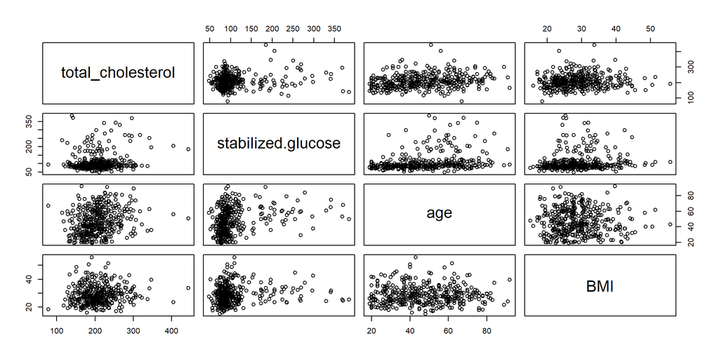

Στο παραπάνω “pairplot” εμφανίζονται οι συχετίσεις που έχουν μεταξύ τους κάποιες μεταβλητές.

Φαίνεται πως υπάρχει συσχέτιση εκεί που μαζέυονται οι τιμές , ενώ αντίθετα δεν υπάρχει ιδιαίτερη συσχέτιση μεταξύ BMI και age καθώς οι τιμές είναι διάσπαρτα κατανεμημένες. Αυτό επιβεβαιώνεται, καθώς για τον υπολογισμό του BMI δεν λογίζεται η ηλικία.

## Διαγράμματα μεταβλητών σχετικά με την τοποθεσία.

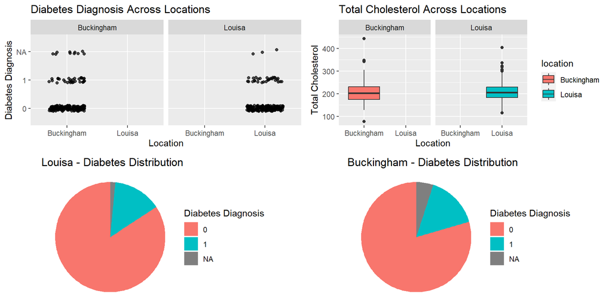

Στα παραπάνω σχήματα, αντλούμε πληροφορία μεταβλητών σχετικά με την τοποθεσία. Παρατηρούμε πως και στις δυο περιοχές οι ανθρωποι με διαβήτη είναι αρκετά λιγότεροι σε σχέση με τους ανθρώπους που δεν πάσχουν απο διαβήτη. Στο διάγραμμα με τα boxplot, βλέπουμε πως οι τιμές κυμαίνονται γύρω απο το μέσο και ακολουθούν κανονική κατανομή. Όπως και σε προηγούμενα διαγράμματα παρατηρούνται τιμές που χαρακτηρίζονται έκτοπες! Στη περιοχή της Λουίζας υπάρχουν περισσότερες τέτοιες τιμές σε σχέση με το Μπάκιγχαμ.Αυτη την παρατήρηση ενδεχομενως να μπορούσε να την αξιοποιήσει ένας άνθρωπος ειδικός επι του θέματος.

**Διαχείριση έκτοπων τιμών (outliers):**

Κατα τη διερεύνηση των μεταβλητών και τη δημουργία διαγραμμάτων, παρατηρούνται συχνά έκτοπες τιμές που βρίσκονται μακριά απο την κατανομή και το σύνολο των δεδομένων.Έκτοπη τιμή ή μέτρηση (outlier) ονομάζονται οι **ακραίες τιμές** που επηρεάζουν κατά πολύ τις τιμές Μ, SD του δείγματος, ενώ τυπικά βρίσκονται σε απόσταση ± 3 SD από το M.

Για τη διαχείριση των έκτοπων τιμών, χρειάζεται αρχικά η εύρεση τους και στη συνέχεια η αξιολόγηση για το αν χρειάζεται η παραμονή τους ή οχι στη σχετική μελέτη που γίνεται.

Στα παραπάνω διαγράμματα,οι έκτοπες τιμές φαίνονται και σχολιάζονται στην επεξήγηση κάθε plot. Αυτό που μπορούμε να κάνουμε ωστε να τα διαχειριστούμε και να τα ελέγξει ο υπεύθυνος και σχετικός με το αντικείμενο επιστήμονας, είναι να τα εντοπίσουμε και να τα εκχωρήσουμε σε ενα πίνακα (dataframe) καταγράφοντας όλες τις ιδιότητες που έχουν και τις κατηγορίες που ανήκουν.

**Παρακάτω** φαίνεται ο κώδικας δημιουργίας θηκογραμμάτων (Ίδιο με Ερώτημα πρώτο), η εύρεση των έκτοπων τιμών καθώς και η αποθήκευση του σε πίνακα με τις ιδιότητες τους.

```r
# Δημιουργία Διαγράμματος
plot_age_chol <- ggplot(data, aes(x = reorder(age_cat, -weight, median), y = total_cholesterol)) +
  geom_boxplot() +
  geom_boxplot(fill = "coral") +
  geom_jitter(width = 0.2, alpha = 0.5, color = "blue") +
  ggtitle("") +
  labs(y = "total_cholesterol", x = "Age cat")



ggplotly(plot_age_chol)
```

[interactive chart not shown]

```r
# Εκτοπες τιμές (Outliers)
boxplot_outliers <- data %>%
  group_by(age_cat) %>%
  mutate(
    Q1 = quantile(total_cholesterol, 0.25, na.rm = TRUE),
    Q3 = quantile(total_cholesterol, 0.75, na.rm = TRUE),
    IQR = Q3 - Q1,
    lower_bound = Q1 - 1.5 * IQR,
    upper_bound = Q3 + 1.5 * IQR
  ) %>%
  filter(total_cholesterol < lower_bound | total_cholesterol > upper_bound) %>%
  select(age_cat, total_cholesterol)


print(boxplot_outliers)
```

```
## # A tibble: 14 × 2
## # Groups:   age_cat [4]
##    age_cat total_cholesterol
##      <int>             <dbl>
##  1       4                78
##  2       3               443
##  3       2               347
##  4       3               342
##  5       1               305
##  6       3               404
##  7       1               300
##  8       1               298
##  9       4               306
## 10       2               307
## 11       2               337
## 12       2               322
## 13       2               302
## 14       4               301
```

```r
oultiers_of_boxplot = as.data.frame(boxplot_outliers)
```

**Ερώτημα δεύτερο :**

Στο δεύτερο μέρος της εργασίας, μας δόθηκε ενα σετ δεδομένων με αρκετές μη διαθέσιμες (**NA**) τιμές. Στόχος ήταν η συμπλήρωση των τιμών NA με κάποια συγκεκριμένη μέθοδο ώστε οι εκτιμώμενες τιμές να είναι όσο πιο κοντά στις πραγματικές τιμές.

Έπειτα απο έρευνα σχετικά με τους τρόπους που υπάρχουν για συμπλήρωση δεδομένων NA, εξετάστηκαν 4 τρόποι με στόχο την υλοποίηση αυτού που ταιριάζει καλύτερα στα αρχικά δεδομένα.

Για την επιλογή και ρύθμιση παραμέτρων σε κάθε μέθοδο, αντλήθηκαν δεδομένα απο τις παρακάτω πηγές:

[An introduction to data cleaning with R](https://cran.r-project.org/doc/contrib/de_Jonge+van_der_Loo-Introduction_to_data_cleaning_with_R.pdf)  
[Statistical Data Cleaning with Applications in R](https://onlinelibrary.wiley.com/doi/book/10.1002/9781118897126)  
[Data Cleansing](https://rpubs.com/Machmurka/1026747)  
[Edav.info](https://edav.info/missing-data.html)

**1.** Imputed **MEAN**

```r
library(mice)
library(caret)
```

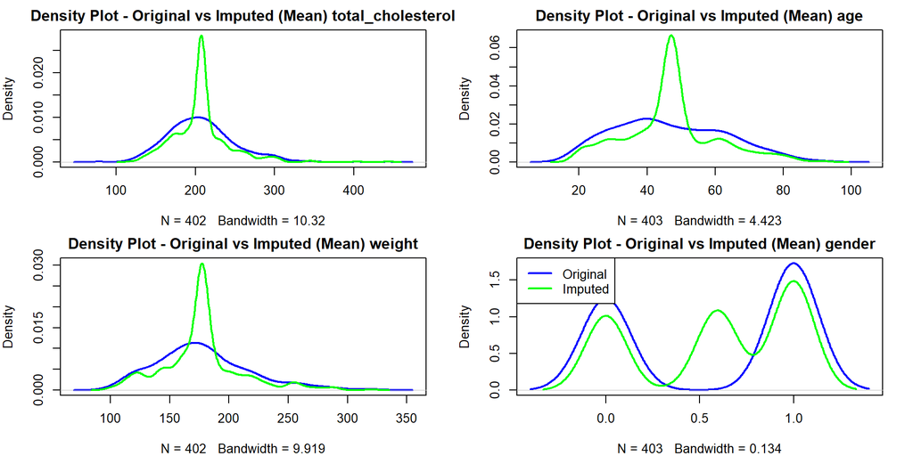

```r
library(ggplot2)
library(openxlsx)


set.seed(103)
imputed_mean <- mice::mice(data_NA, method = "mean", m = 5)
#  Δημιουργία νέου σετ με τα συμπληρωμένα κελιά.
imputed_mean <- complete(imputed_mean)


# Αυθεντικά δεδομένα
original_variables <- data[c("total_cholesterol", "age", "weight", "gender")]

# Δεδομένα με τη συμπλήρωση.
imputed_variables_mean <- imputed_mean[c("total_cholesterol", "age", "weight", "gender")]

# Ρυθμίσεις παραμέτρων του διαγράμματος.
par(mfrow = c(2, 2), mar = c(4, 4, 2, 2))

# Συγκριση μέσω διαγράμματος πυκνότητας.
for (variable in names(original_variables)) {
  density_original <- density(original_variables[[variable]], na.rm = TRUE)
  density_imputed <- density(imputed_variables_mean[[variable]], na.rm = TRUE)

  plot(density_original, main = paste("Density Plot - Original vs Imputed (Mean)", variable),
       col = "blue", lwd = 2, ylim = c(0, max(density_original$y, density_imputed$y)))
  lines(density_imputed, col = "green", lwd = 2)
}

# Υπόμνημα
legend("topleft", legend = c("Original", "Imputed"), col = c("blue", "green"), lwd = 2)
```

Στην περίπτωση της μεθόδου **mean**, η απουσιάζουσες τιμές αντικαθίστανται με το μέσο όρο των γνωστών τιμών της αντίστοιχης μεταβλητής. Η προσέγγιση αυτή αποτελεί μια απλή προσέγγιση και δεν λαμβάνει υπόψη πιθανές σχέσεις ή πολυπλοκότερες δομές που μπορεί να υπάρχουν στα δεδομένα.Φαίνεται πως οι κατανομές μεταξύ των αρχικών και τελικών δεδομένων δεν ταιριάζουν καθόλου.

**2.** Imputed **Norm-Logreg**

```r
library(mice)
init = mice(data_NA, maxit=0)
meth = init$method
predM = init$predictorMatrix


# Μέθοδος για κάθε μεταβλητή που εξετάζεται
meth[c("total_cholesterol")]="norm"
meth[c("gender")]="logreg"
meth[c("age")]="norm"
meth[c("weight")]="norm"


set.seed(103)
imputed_norm = mice(data_NA, method=meth, predictorMatrix=predM, m=5)
```

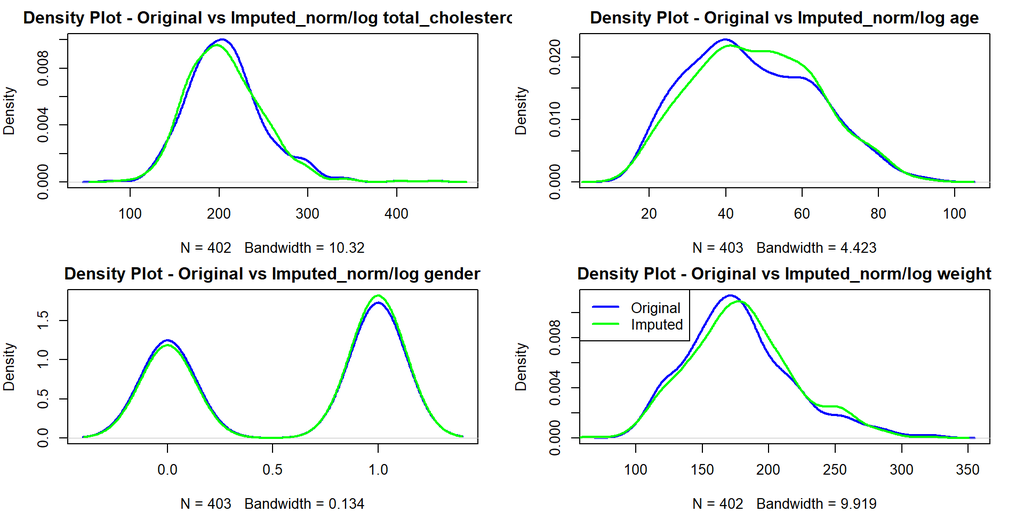

```r
# Δημιουργία νέου σετ με τα συμπληρωμένα κελιά.
imputed_norm <- complete(imputed_norm)


# Εξαγωγή αρχικών μεταβλητών ενδιαφέροντος από το αρχικό σύνολο δεδομένων.
original_variables_norm <- data


imputed_variables_norm <- imputed_norm

# Ρυθμίσεις παραμέτρων του διαγράμματος.
par(mfrow = c(2, 2), mar = c(4, 4, 2, 2))
# Συγκριση μέσω διαγράμματος πυκνότητας.
for (variable in names(original_variables_norm)) {
  if (is.numeric(original_variables_norm[[variable]]) && is.numeric(imputed_variables_norm[[variable]])) {
    density_original <- density(original_variables_norm[[variable]], na.rm = TRUE)
    density_imputed <- density(imputed_variables_norm[[variable]], na.rm = TRUE)

    plot(density_original, main = paste("Density Plot - Original vs Imputed_norm/log", variable),
         col = "blue", lwd = 2, ylim = c(0, max(density_original$y, density_imputed$y)))
    lines(density_imputed, col = "green", lwd = 2)
  }
}


# Υπόμνημα
legend("topleft", legend = c("Original", "Imputed"), col = c("blue", "green"), lwd = 2)
```

Στη παραπάνω μεθοδο χρησιμοποιήσαμε:

1. **norm** (Κανονικοποίηση): Χρησιμοποιείται για αριθμητικές μεταβλητές όπως η **“total_cholesterol**,” “**age**,” και “**weight**”. Κανονικοποιεί τη διανομή των δεδομένων για να αντιμετωπίσει τις απουσιάζουσες τιμές. Αντικαθιστά τις απουσιάζουσες τιμές με νέες τιμές που ταιριάζουν στη γενική κατανομή των δεδομένων.
2. **logreg** (Λογιστική Παλινδρόμηση): Χρησιμοποιείται για κατηγορικές μεταβλητές όπως η “**gender**”. Προβλέπει τις απουσιάζουσες τιμές με βάση τις υπόλοιπες παρατηρήσεις, χρησιμοποιώντας ένα μοντέλο λογιστικής παλινδρόμησης για την εκτίμηση των πιθανοτήτων κάθε κατηγορίας.

**3.** Imputed **PMM-Logreg**

```r
library(mice)
init = mice(data_NA, maxit=0)
meth = init$method
predM = init$predictorMatrix


# Μέθοδος για κάθε μεταβλητή που εξετάζεται
meth[c("total_cholesterol")]="pmm"
meth[c("gender")]="logreg"
meth[c("age")]="pmm"
meth[c("weight")]="pmm"


set.seed(103)
imputed_pmm = mice(data_NA, method=meth, predictorMatrix=predM, m=5)
```

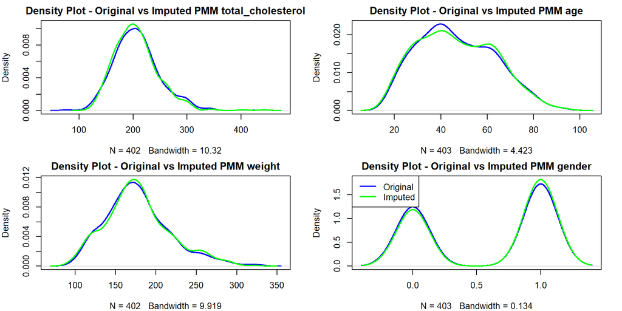

```r
# Δημιουργία νέου σετ με τα συμπληρωμένα κελιά.
imputed_pmm <- complete(imputed_pmm)




# Εξαγωγή αρχικών μεταβλητών ενδιαφέροντος από το αρχικό σύνολο δεδομένων.
original_variables <- data[c("total_cholesterol", "age", "weight", "gender")]


imputed_variables_pmm <- complete(imputed_pmm)[c("total_cholesterol", "age", "weight", "gender")]

# Ρυθμίσεις παραμέτρων του διαγράμματος.
par(mfrow = c(2, 2), mar = c(4, 4, 2, 2))

#  Συγκριση μέσω διαγράμματος πυκνότητας.
for (variable in names(original_variables)) {
  density_original <- density(original_variables[[variable]], na.rm = TRUE)
  density_imputed <- density(imputed_variables_pmm[[variable]], na.rm = TRUE)

  plot(density_original, main = paste("Density Plot - Original vs Imputed PMM", variable),
       col = "blue", lwd = 2, ylim = c(0, max(density_original$y, density_imputed$y)))
  lines(density_imputed, col = "green", lwd = 2)
}

# Υπόμνημα
legend("topleft", legend = c("Original", "Imputed"), col = c("blue", "green"), lwd = 2)
```

Στη παραπάνω μέθοδο χρησιμοποιήσαμε :

1. **pmm (Predictive Mean Matching)** : Η μέθοδος PMM χρησιμοποιείται για αριθμητικές μεταβλητές όπως η “total_cholesterol,” “age,” και “weight.” Εκτιμά τις απουσιάζουσες τιμές με βάση την πρόβλεψη της μέσης τιμής από παρατηρήσεις που είναι παρόμοιες με αυτές που λείπουν. Στη συνέχεια, επιλέγει τυχαία μια από αυτές τις παρατηρήσεις για να αντικαταστήσει την απουσιάζουσα τιμή.
2. **logreg** (Λογιστική Παλινδρόμηση): Χρησιμοποιείται για κατηγορικές μεταβλητές όπως η “**gender**”. Προβλέπει τις απουσιάζουσες τιμές με βάση τις υπόλοιπες παρατηρήσεις, χρησιμοποιώντας ένα μοντέλο λογιστικής παλινδρόμησης για την εκτίμηση των πιθανοτήτων κάθε κατηγορίας.

Εδώ φαίνεται πως οι κατανομές ταιριάζουν καλύτερα σε σχέση με τις προηγούμενες μεθόδους.

**4.** Imputed **Cart-Logreg**

```r
library(mice)
init = mice(data_NA, maxit=0)
meth = init$method
predM = init$predictorMatrix


# Μέθοδος για κάθε μεταβλητή που εξετάζεται
meth[c("total_cholesterol")]="cart"
meth[c("gender")]="logreg"
meth[c("age")]="cart"
meth[c("weight")]="cart"


set.seed(103)
imputed_cart = mice(data_NA, method=meth, predictorMatrix=predM, m=5)
```

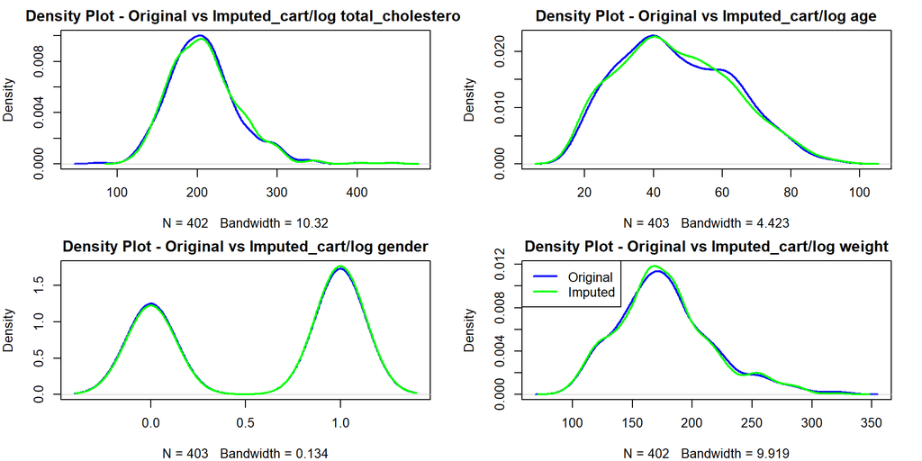

```r
# Δημιουργία νέου σετ με τα συμπληρωμένα κελιά.
imputed_cart <- complete(imputed_cart)


# Εξαγωγή αρχικών μεταβλητών ενδιαφέροντος από το αρχικό σύνολο δεδομένων.
original_variables_cart <- data


imputed_variables_cart <- imputed_cart

# Ρυθμίσεις παραμέτρων του διαγράμματος.
par(mfrow = c(2, 2), mar = c(4, 4, 2, 2))

# Συγκριση μέσω διαγράμματος πυκνότητας.
for (variable in names(original_variables_cart)) {
  if (is.numeric(original_variables_cart[[variable]]) && is.numeric(imputed_variables_cart[[variable]])) {
    density_original <- density(original_variables_cart[[variable]], na.rm = TRUE)
    density_imputed <- density(imputed_variables_cart[[variable]], na.rm = TRUE)

    plot(density_original, main = paste("Density Plot - Original vs Imputed_cart/log", variable),
         col = "blue", lwd = 2, ylim = c(0, max(density_original$y, density_imputed$y)))
    lines(density_imputed, col = "green", lwd = 2)
  }
}


# Υπόμνημα
legend("topleft", legend = c("Original", "Imputed"), col = c("blue", "green"), lwd = 2)
```

Στη παραπάνω μέθοδο χρησιμοποιήσαμε :

1. **cart (Classification and Regression Trees)**: Η μέθοδος CART χρησιμοποιείται για αριθμητικές μεταβλητές όπως η “total_cholesterol,” “age,” και “weight.” Χρησιμοποιεί ένα δέντρο απόφασης για να εκτιμήσει τις απουσιάζουσες τιμές με βάση τις τιμές άλλων μεταβλητών, επιλέγοντας την καλύτερη δυνατή ανακατασκευή μέσω απλών κανόνων αποφάσεων.
2. **logreg** (Λογιστική Παλινδρόμηση): Χρησιμοποιείται για κατηγορικές μεταβλητές όπως η “**gender**”. Προβλέπει τις απουσιάζουσες τιμές με βάση τις υπόλοιπες παρατηρήσεις, χρησιμοποιώντας ένα μοντέλο λογιστικής παλινδρόμησης για την εκτίμηση των πιθανοτήτων κάθε κατηγορίας.

Όπως φαίνεται παραπάνω η συγκεκριμένη μέθοδος ταιριάζει καλύτερα σε σχέση με τα πραγματικά αρχικά δεδομένα. Σε όλες τις μεταβλητές υπάρχει καλύτερη εκτίμηση.

**Συμπεράσματα**

Η διαδικάσια συμπλήρωσης ΝΑ τιμών, φάνηκε αρκετά δυσκολη στην πράξη.Δεν υπάρχει καμία μέθοδος που να μπορεί να εκτιμήσει σωστά όλες τις τιμές.Σε κάθε μέθοδο βλέπουμε πως υπάρχουν τιμές που μοιάζουν και είναι κοντα με τις πραγματικές, ενω αλλες δυστυχώς όχι.Εγινε επιλογή της μεθόδου **cart και logreg**, καθώς απέδιδε λίγο καλύτερα απο την pmm και αρκετά καλύτερα απο τις υπόλοιπες.Παρατηρούμε πως οι κατανομές των αρχικών δεδομένων και αυτών που συμπληρώθηκαν μοιάζουν αρκετά, παρατηρώντας σημάδια απόκλισης.

Επιπλέον, υπάρχουν τιμές που θα μπορούσε να ειναι έκτοπες. Αυτό μπορεί να δημιουργήσει λανθασμένο υπολογισμο της τιμής του κελιού.

Αυτό που χρειάζεται είναι η άμεση συνεργασία με τον επιστήμονα και μελετητή του φαινομένου- αντικειμένου της μελέτης,καθώς θα δώσει σημαντική και ενδεχομένως άγνωστη πληροφορία.

```
                                             Θεσσαλονίκη 18-11-2023

                                         Γεώργιος Δημήτριος Γκολογκίνας

                                    Υπεύθυνος καθηγητής : κ.Γεώργιος Ευαγγελίδης
```